# Global Sewage Project

Predicting clinical resistance prevalence using sewage metagenomic data

Antti Karkman, 2020

# Short Introduction

## Objectives

The main objective of this project is to use untreated sewage as a marker for antibiotic resistance prevalence in clinical pathogens.  
We want to test whether sewage meatgenomic could be used to predict clinical resistance.

## The Data

Metagenomic sequencing data from untreated sewage comes from an article in *Nature Communications* [Global monitoring of antimicrobial resistance based on metagenomics analyses of urban sewage.](https://doi.org/10.1038/s41467-019-08853-3)  
The raw sequence data from this study was downloaded from [ENA](https://www.ebi.ac.uk/ena) under project [ERP015409](https://www.ebi.ac.uk/ena/data/view/PRJEB13831).

The data consists of 234 sewage metagenomemes from 62 countries. The antibiotic resistance genes were annotated against [ResFinder v.3.1.0](https://bitbucket.org/genomicepidemiology/resfinder) database and *intI1* integrase gene against MobileGeneticElementDatabase.

The clinical resistance data for *E. coli* against four different classes of antibiotics, aminopenicillins, fluoroquinolones, 3rd generation cephalosporins and aminoglycosides was collected from different surveillance networks. Only data from more than 100 isolates was considered reliable and included in the actual analyses.  
In addition, aggregated resistance index from Collignon *et al.*, 2018 was used in the study.

Socio-economical factors were retrieved from [The World Bank Databank](https://databank.worldbank.org/source/health-nutrition-and-population-statistics).

All ARG and *intI1* integrase gene counts were normalized to the amount of sequence data (million bases). Since the clinical resistance data is on country level, mean of the normalized gene count data was taken for countries with more than one sewage sample.

All data has been gathered to one data frame and is available in the `Data` folder.

# Data Analyses

Load all needed libraries.

```r
library(vegan)
library(tidyverse)
library(MASS)
#library(gridExtra)
library(GGally)
library(betareg)
library(lmtest)
library(pheatmap)
library(patchwork)
```

Read in the data and have a look.

```r
# Data
load("../Data/GlobalSewage.R", verbose=TRUE)
```

```
## Loading objects:
##   ResData
```

```r
glimpse(ResData)
```

```
## Rows: 62
## Columns: 25
## Groups: IncomeGroup [5]
## $ Country              <chr> "Albania", "Australia", "Austria", "Bulgaria", "…
## $ country_code         <chr> "ALB", "AUS", "AUT", "BGR", "BRA", "BWA", "CAN",…
## $ Continent            <chr> "Europe", "Oceania", "Europe", "Europe", "Americ…
## $ `AP_(R%)`            <dbl> NA, 54.0, 50.5, 78.0, NA, NA, NA, 46.0, 88.0, NA…
## $ `AP_(n)`             <dbl> NA, 4353, 5094, 186, NA, NA, NA, 4346, 4166, NA,…
## $ `FQ_(R%)`            <dbl> NA, 12.0, 19.8, 42.2, NA, NA, 21.0, 16.0, 54.0, …
## $ `FQ_(n)`             <dbl> NA, 4353, 5278, 237, NA, NA, 336, 4686, 4166, NA…
## $ `3GC_(R%)`           <dbl> NA, 11.0, 10.0, 41.6, NA, NA, 9.0, 9.0, 64.0, NA…
## $ `3GC_(n)`            <dbl> NA, 4353, 5267, 238, NA, NA, 336, 4700, 4166, NA…
## $ `AG_(R%)`            <dbl> NA, 8.0, 7.8, 34.8, NA, NA, 8.0, 9.0, 43.0, NA, …
## $ `AG_(n)`             <dbl> NA, 4353, 5248, 210, NA, NA, 336, 4665, 4166, NA…
## $ AverageAll           <dbl> NA, 9.26, 10.59, 32.07, 38.89, NA, 10.99, 9.96, …
## $ mean_res             <dbl> 4.4529596, 2.8117185, 2.4786086, 2.6029876, 5.24…
## $ mean_int             <dbl> 0.05088502, 0.06964735, 0.03144110, 0.05634586, …
## $ mean_coliRes         <dbl> 2.80035407, 1.44382428, 1.28256654, 1.56181607, …
## $ mean_topColi         <dbl> 0.12743425, 0.06500830, 0.04387622, 0.12377560, …
## $ mean_AG              <dbl> 0.22147902, 0.14655638, 0.11192652, 0.23512583, …
## $ mean_BL              <dbl> 0.56978146, 0.37820636, 0.26635683, 0.39331702, …
## $ mean_FQ              <dbl> 0.021570135, 0.083487707, 0.038700191, 0.0296148…
## $ GDP                  <dbl> 10970, 43987, 44253, 16999, 14700, 15032, 43149,…
## $ basic_sanitation     <dbl> 97.7, 100.0, 100.0, 86.0, 86.1, 60.0, 98.5, 99.9…
## $ basic_drinking_water <dbl> 91.4, 100.0, 100.0, 99.3, 97.5, 79.2, 98.9, 100.…
## $ urban_population     <dbl> 57.4, 85.7, 57.7, 74.0, 85.8, 67.2, 81.3, 73.7, …
## $ access_electricity   <dbl> 100.0, 100.0, 100.0, 100.0, 99.7, 58.5, 100.0, 1…
## $ IncomeGroup          <chr> NA, "High income", "High income", "Upper middle …
```

The data consists of sewage metagenomic resistance marker data, clinical resistance data and socio-economical factors for 62 countries. The clinical resistance data shows the proportion of resistant isolates (`%R`) and total number of isolates (`n`).  
`Average All` is the aggregated resistance index from Collignon *et al.*, 2018.  
`mean_res` is the normalizsed resistance gene count and `mean_int` the normalized *intI1* integrase gene count.  
`mean_coliRes`and `mean_topColi` are all and top 10 *E. coli* associated ARGs in the sewage metagenomes, respectively.  
`mean_AG`, `mean_BL` and `mean_FQ` are the normalized gene counts for resistance genes against aminoglycosides, beta-lactams and fluoroquinolones, respectively.  
`GDP`, `basic_sanitation` and `urban_population` are the socio-economical factors used in the models and taken from World Bank Databank.

## Main Article

### *E. coli* clinical resistance models based on ten most common ARGs in *E. coli*

The first and maybe most obvious approach was to use the 10 most common ResFinder ARGs in publicly available *E. coli* genomes in predicting clinical resistance in *E. coli*.  
Results from beta regression models for the four resistance categories and Figure 1 from the article presented below.

#### Clinical aminopenicillin resistance

```r
tmp <- ResData %>% filter(`AP_(n)`>100)
tmp$y = tmp$`AP_(R%)`/100
breg <- betareg(y ~ mean_topColi, data=tmp, link="loglog")
summary(breg)
```

```
##
## Call:
## betareg(formula = y ~ mean_topColi, data = tmp, link = "loglog")
##
## Standardized weighted residuals 2:
##     Min      1Q  Median      3Q     Max
## -2.2304 -0.5217 -0.0417  0.3678  2.9636
##
## Coefficients (mean model with loglog link):
##              Estimate Std. Error z value Pr(>|z|)
## (Intercept)   0.08767    0.12986   0.675      0.5
## mean_topColi  8.54151    1.52922   5.586 2.33e-08 ***
##
## Phi coefficients (precision model with identity link):
##       Estimate Std. Error z value Pr(>|z|)
## (phi)   13.715      3.289    4.17 3.04e-05 ***
## ---
## Signif. codes:  0 '***' 0.001 '**' 0.01 '*' 0.05 '.' 0.1 ' ' 1
##
## Type of estimator: ML (maximum likelihood)
## Log-likelihood: 23.48 on 3 Df
## Pseudo R-squared: 0.405
## Number of iterations: 22 (BFGS) + 3 (Fisher scoring)
```

```r
new_int <- data.frame(mean_topColi=seq(min(tmp$mean_topColi), max(tmp$mean_topColi)+0.05, 0.05))
new_int$y <- predict(breg, newdata=new_int)

p1 <- ggplot(tmp, aes(mean_topColi, y)) + geom_point(pch=21, size=5, fill="skyblue") +
  geom_line(aes(mean_topColi, y), data=new_int, linetype="twodash", color="blue", size=1) + theme_classic() +
  scale_size(limits=c(50,100), breaks=c(60, 80, 100)) + scale_x_continuous(limits=c(0, 0.35)) +
  labs(x="Relative ARG abundance", y="Proportion of resistant clinical isolates", title="A")
```

#### Clinical fluoroquinolone resistance

```r
tmp <- ResData %>% filter(`FQ_(n)`>100)
tmp$y = tmp$`FQ_(R%)`/100
breg <- betareg(y ~ mean_topColi, data=tmp, link="loglog")
summary(breg)
```

```
##
## Call:
## betareg(formula = y ~ mean_topColi, data = tmp, link = "loglog")
##
## Standardized weighted residuals 2:
##     Min      1Q  Median      3Q     Max
## -2.7415 -0.4312 -0.0534  0.6384  2.0625
##
## Coefficients (mean model with loglog link):
##              Estimate Std. Error z value Pr(>|z|)
## (Intercept)   -0.6723     0.1004  -6.696 2.14e-11 ***
## mean_topColi   6.0567     1.0462   5.789 7.07e-09 ***
##
## Phi coefficients (precision model with identity link):
##       Estimate Std. Error z value Pr(>|z|)
## (phi)   13.323      3.149    4.23 2.33e-05 ***
## ---
## Signif. codes:  0 '***' 0.001 '**' 0.01 '*' 0.05 '.' 0.1 ' ' 1
##
## Type of estimator: ML (maximum likelihood)
## Log-likelihood:    26 on 3 Df
## Pseudo R-squared: 0.4906
## Number of iterations: 15 (BFGS) + 4 (Fisher scoring)
```

```r
new_int <- data.frame(mean_topColi=seq(min(tmp$mean_topColi), max(tmp$mean_topColi)+0.05, 0.05))
new_int$y <- predict(breg, newdata=new_int)

p2 <- ggplot(tmp, aes(mean_topColi, y)) + geom_point(pch=21, size=5, fill="skyblue") +
  geom_line(aes(mean_topColi, y), data=new_int, linetype="twodash", color="blue", size=1) + theme_classic() +
  scale_size(limits=c(50,100), breaks=c(60, 80, 100)) + scale_x_continuous(limits=c(0, 0.35)) +
  labs(x="Relative ARG abundance", y="Proportion of resistant clinical isolates", title="B")
```

#### Clinical 3rd generation cephalosporin resistance

```r
tmp <- ResData %>% filter(`3GC_(n)`>100)
tmp$y = tmp$`3GC_(R%)`/100
breg <- betareg(y ~ mean_topColi, data=tmp, link="loglog")
summary(breg)
```

```
##
## Call:
## betareg(formula = y ~ mean_topColi, data = tmp, link = "loglog")
##
## Standardized weighted residuals 2:
##     Min      1Q  Median      3Q     Max
## -3.5030 -0.5427 -0.1212  0.4388  2.0227
##
## Coefficients (mean model with loglog link):
##              Estimate Std. Error z value Pr(>|z|)
## (Intercept)   -0.8483     0.1321  -6.421 1.35e-10 ***
## mean_topColi   6.3569     1.3598   4.675 2.94e-06 ***
##
## Phi coefficients (precision model with identity link):
##       Estimate Std. Error z value Pr(>|z|)
## (phi)    6.613      1.564   4.228 2.36e-05 ***
## ---
## Signif. codes:  0 '***' 0.001 '**' 0.01 '*' 0.05 '.' 0.1 ' ' 1
##
## Type of estimator: ML (maximum likelihood)
## Log-likelihood: 21.52 on 3 Df
## Pseudo R-squared: 0.3938
## Number of iterations: 12 (BFGS) + 5 (Fisher scoring)
```

```r
new_int <- data.frame(mean_topColi=seq(min(tmp$mean_topColi), max(tmp$mean_topColi)+0.05, 0.05))
new_int$y <- predict(breg, newdata=new_int)

p3 <- ggplot(tmp, aes(mean_topColi, y)) + geom_point(pch=21, size=5, fill="skyblue") +
  geom_line(aes(mean_topColi, y), data=new_int, linetype="twodash", color="blue", size=1) + theme_classic() +
  scale_size(limits=c(50,100), breaks=c(60, 80, 100)) + scale_x_continuous(limits=c(0, 0.35)) +
  labs(x="Relative ARG abundance", y="Proportion of resistant clinical isolates", title="C")
```

#### Clinical aminoglycoside resistance

```r
tmp <- ResData %>% filter(`AG_(n)`>100)
tmp$y = tmp$`AG_(R%)`/100
breg <- betareg(y ~ mean_topColi, data=tmp, link="loglog")
summary(breg)
```

```
##
## Call:
## betareg(formula = y ~ mean_topColi, data = tmp, link = "loglog")
##
## Standardized weighted residuals 2:
##     Min      1Q  Median      3Q     Max
## -3.2747 -0.4971 -0.1390  0.3243  2.1603
##
## Coefficients (mean model with loglog link):
##              Estimate Std. Error z value Pr(>|z|)
## (Intercept)   -0.7967     0.0874  -9.115  < 2e-16 ***
## mean_topColi   2.1374     0.8162   2.619  0.00883 **
##
## Phi coefficients (precision model with identity link):
##       Estimate Std. Error z value Pr(>|z|)
## (phi)    15.31       3.76   4.071 4.68e-05 ***
## ---
## Signif. codes:  0 '***' 0.001 '**' 0.01 '*' 0.05 '.' 0.1 ' ' 1
##
## Type of estimator: ML (maximum likelihood)
## Log-likelihood: 36.54 on 3 Df
## Pseudo R-squared: 0.2014
## Number of iterations: 15 (BFGS) + 4 (Fisher scoring)
```

```r
new_int <- data.frame(mean_topColi=seq(min(tmp$mean_topColi), max(tmp$mean_topColi)+0.05, 0.05))
new_int$y <- predict(breg, newdata=new_int)

p4 <- ggplot(tmp, aes(mean_topColi, y)) + geom_point(pch=21, size=5, fill="skyblue") +
  geom_line(aes(mean_topColi, y), data=new_int, linetype="twodash", color="blue", size=1) + theme_classic() +
  scale_size(limits=c(50,100), breaks=c(60, 80, 100)) + scale_x_continuous(limits=c(0, 0.35)) +
  labs(x="Relative ARG abundance", y="Proportion of resistant clinical isolates", title="D")
```

#### Figure 1

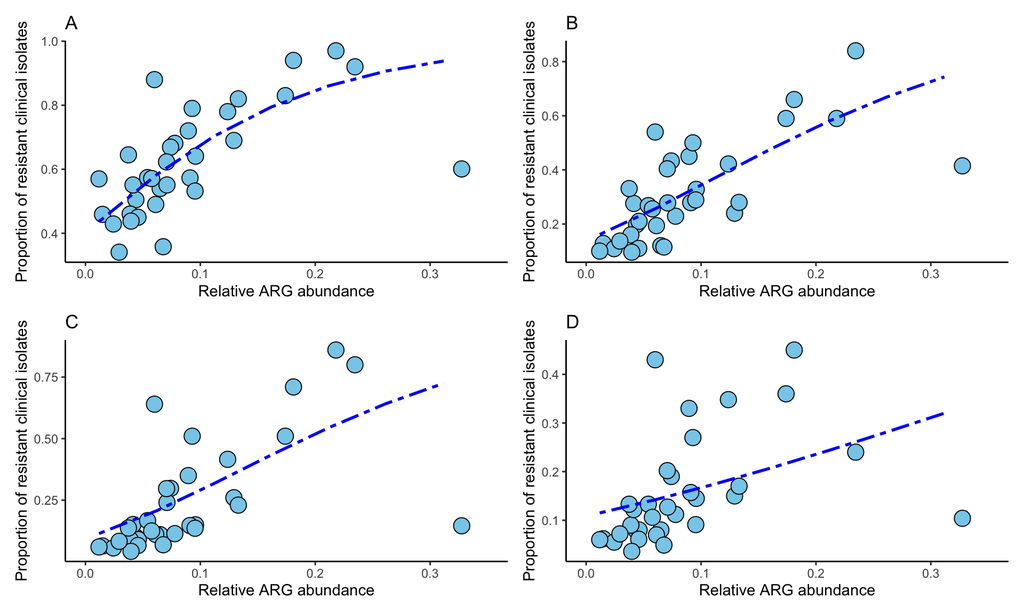

```r
(p1 + p2) /  (p3 + p4)
```

**Fig. 1: E. coli clinical resistance models based on ten most common ARGs in E. coli**

### *E. coli* clinical resistance models based on intI1 integrase gene

Next spet was to use *intI1* integrase gene as a proxy for antibiotic resistance gene prevalence in sewage samples. The results from this approach ands Figure 2 from the article below.

#### Clinical aminopenicillin resistance

```r
tmp <- ResData %>% filter(`AP_(n)`>100)
tmp$y = tmp$`AP_(R%)`/100
breg <- betareg(y ~ mean_int, data=tmp, link="loglog")
summary(breg)
```

```
##
## Call:
## betareg(formula = y ~ mean_int, data = tmp, link = "loglog")
##
## Standardized weighted residuals 2:
##     Min      1Q  Median      3Q     Max
## -1.7796 -0.8594 -0.0775  0.8627  2.1615
##
## Coefficients (mean model with loglog link):
##             Estimate Std. Error z value Pr(>|z|)
## (Intercept)  0.02805    0.13275   0.211    0.833
## mean_int    10.84719    1.88498   5.755 8.69e-09 ***
##
## Phi coefficients (precision model with identity link):
##       Estimate Std. Error z value Pr(>|z|)
## (phi)    15.49       3.72   4.165 3.12e-05 ***
## ---
## Signif. codes:  0 '***' 0.001 '**' 0.01 '*' 0.05 '.' 0.1 ' ' 1
##
## Type of estimator: ML (maximum likelihood)
## Log-likelihood: 26.03 on 3 Df
## Pseudo R-squared: 0.5949
## Number of iterations: 43 (BFGS) + 3 (Fisher scoring)
```

```r
new_int <- data.frame(mean_int=seq(min(tmp$mean_int), max(tmp$mean_int)+0.05, 0.05))
new_int$y <- predict(breg, newdata=new_int)

p1 <- ggplot(tmp, aes(mean_int, y)) + geom_point(pch=21, size=5, fill="skyblue") +
  geom_line(aes(mean_int, y), data=new_int, linetype="twodash", color="blue", size=1) + theme_classic() +
  scale_size(limits=c(50,100), breaks=c(60, 80, 100)) + scale_x_continuous(limits=c(0, 0.25)) +
  labs(x=expression(paste("Relative ", italic("intI1"), " abundance", sep=" ")), y="Proportion of resistant clinical isolates", title="A")
```

#### Clinical fluoroquinolone resistance

```r
tmp <- ResData %>% filter(`FQ_(n)`>100)
tmp$y = tmp$`FQ_(R%)`/100
breg <- betareg(y ~ mean_int, data=tmp, link="loglog")
summary(breg)
```

```
##
## Call:
## betareg(formula = y ~ mean_int, data = tmp, link = "loglog")
##
## Standardized weighted residuals 2:
##     Min      1Q  Median      3Q     Max
## -2.0159 -0.6936  0.0341  0.9617  1.4457
##
## Coefficients (mean model with loglog link):
##             Estimate Std. Error z value Pr(>|z|)
## (Intercept)  -0.7660     0.1011  -7.579 3.49e-14 ***
## mean_int      8.3148     1.2936   6.428 1.30e-10 ***
##
## Phi coefficients (precision model with identity link):
##       Estimate Std. Error z value Pr(>|z|)
## (phi)   15.929      3.782   4.212 2.53e-05 ***
## ---
## Signif. codes:  0 '***' 0.001 '**' 0.01 '*' 0.05 '.' 0.1 ' ' 1
##
## Type of estimator: ML (maximum likelihood)
## Log-likelihood: 29.05 on 3 Df
## Pseudo R-squared: 0.6604
## Number of iterations: 15 (BFGS) + 4 (Fisher scoring)
```

```r
new_int <- data.frame(mean_int=seq(min(tmp$mean_int), max(tmp$mean_int)+0.05, 0.05))
new_int$y <- predict(breg, newdata=new_int)

p2 <- ggplot(tmp, aes(mean_int, y)) + geom_point(pch=21, size=5, fill="skyblue") +
  geom_line(aes(mean_int, y), data=new_int, linetype="twodash", color="blue", size=1) + theme_classic() +
  scale_size(limits=c(50,100), breaks=c(60, 80, 100)) + scale_x_continuous(limits=c(0, 0.25)) +
  labs(x=expression(paste("Relative ", italic("intI1"), " abundance", sep=" ")), y="Proportion of resistant clinical isolates", title="B")
```

#### Clinical 3rd generation cephalosporin resistance

```r
tmp <- ResData %>% filter(`3GC_(n)`>100)
tmp$y = tmp$`3GC_(R%)`/100
breg <- betareg(y ~ mean_int, data=tmp, link="loglog")
summary(breg)
```

```
##
## Call:
## betareg(formula = y ~ mean_int, data = tmp, link = "loglog")
##
## Standardized weighted residuals 2:
##     Min      1Q  Median      3Q     Max
## -2.5827 -0.7182  0.0696  0.6722  2.3899
##
## Coefficients (mean model with loglog link):
##             Estimate Std. Error z value Pr(>|z|)
## (Intercept)  -1.0358     0.1266  -8.180 2.85e-16 ***
## mean_int      9.6379     1.6151   5.968 2.41e-09 ***
##
## Phi coefficients (precision model with identity link):
##       Estimate Std. Error z value Pr(>|z|)
## (phi)    9.278      2.221   4.178 2.94e-05 ***
## ---
## Signif. codes:  0 '***' 0.001 '**' 0.01 '*' 0.05 '.' 0.1 ' ' 1
##
## Type of estimator: ML (maximum likelihood)
## Log-likelihood: 26.87 on 3 Df
## Pseudo R-squared: 0.6235
## Number of iterations: 21 (BFGS) + 3 (Fisher scoring)
```

```r
new_int <- data.frame(mean_int=seq(min(tmp$mean_int), max(tmp$mean_int)+0.05, 0.05))
new_int$y <- predict(breg, newdata=new_int)

p3 <- ggplot(tmp, aes(mean_int, y)) + geom_point(pch=21, size=5, fill="skyblue") +
  geom_line(aes(mean_int, y), data=new_int, linetype="twodash", color="blue", size=1) + theme_classic() +
  scale_size(limits=c(50,100), breaks=c(60, 80, 100)) + scale_x_continuous(limits=c(0, 0.25)) +
  labs(x=expression(paste("Relative ", italic("intI1"), " abundance", sep=" ")), y="Proportion of resistant clinical isolates", title="C")
```

#### Clinical aminoglycoside resistance

```r
tmp <- ResData %>% filter(`AG_(n)`>100)
tmp$y = tmp$`AG_(R%)`/100
breg <- betareg(y ~ mean_int, data=tmp, link="loglog")
summary(breg)
```

```
##
## Call:
## betareg(formula = y ~ mean_int, data = tmp, link = "loglog")
##
## Standardized weighted residuals 2:
##     Min      1Q  Median      3Q     Max
## -1.6903 -0.5976 -0.0897  0.4839  2.0737
##
## Coefficients (mean model with loglog link):
##             Estimate Std. Error z value Pr(>|z|)
## (Intercept) -0.89686    0.09074  -9.884  < 2e-16 ***
## mean_int     3.88204    1.07225   3.620 0.000294 ***
##
## Phi coefficients (precision model with identity link):
##       Estimate Std. Error z value Pr(>|z|)
## (phi)   17.760      4.368   4.066 4.78e-05 ***
## ---
## Signif. codes:  0 '***' 0.001 '**' 0.01 '*' 0.05 '.' 0.1 ' ' 1
##
## Type of estimator: ML (maximum likelihood)
## Log-likelihood: 38.83 on 3 Df
## Pseudo R-squared: 0.3058
## Number of iterations: 21 (BFGS) + 2 (Fisher scoring)
```

```r
new_int <- data.frame(mean_int=seq(min(tmp$mean_int), max(tmp$mean_int)+0.05, 0.05))
new_int$y <- predict(breg, newdata=new_int)

p4 <- ggplot(tmp, aes(mean_int, y)) + geom_point(pch=21, size=5, fill="skyblue") +
  geom_line(aes(mean_int, y), data=new_int, linetype="twodash", color="blue", size=1) + theme_classic() +
  scale_size(limits=c(50,100), breaks=c(60, 80, 100)) + scale_x_continuous(limits=c(0, 0.25)) +
  labs(x=expression(paste("Relative ", italic("intI1"), " abundance", sep=" ")), y="Proportion of resistant clinical isolates", title="D")
```

#### Figure 2

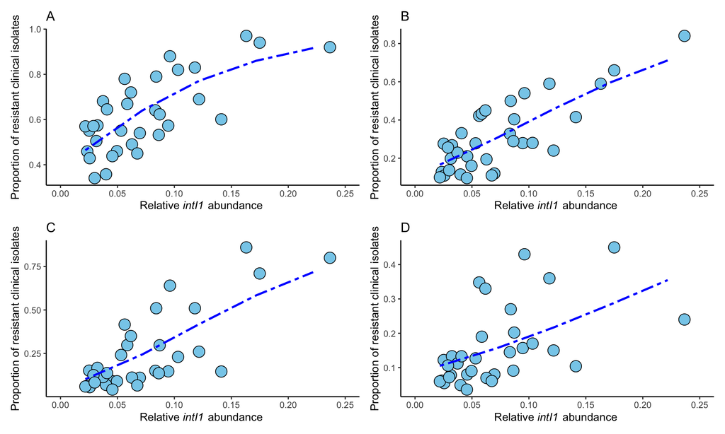

```r
(p1 + p2) /  (p3 + p4)
```

**Fig. 2: E. coli clinical resistance models based on intI1 integrase gene**

### Aggregated resistance model based on intI1 integrase gene

#### With all data

```r
tmp <- ResData
tmp$y = tmp$AverageAll/100
breg <- betareg(y ~ mean_int, data=tmp, link="loglog")
summary(breg)
```

```
##
## Call:
## betareg(formula = y ~ mean_int, data = tmp, link = "loglog")
##
## Standardized weighted residuals 2:
##     Min      1Q  Median      3Q     Max
## -2.5510 -0.8003  0.0782  0.8662  1.8720
##
## Coefficients (mean model with loglog link):
##             Estimate Std. Error z value Pr(>|z|)
## (Intercept) -0.55247    0.08251  -6.696 2.15e-11 ***
## mean_int     2.58303    0.62081   4.161 3.17e-05 ***
##
## Phi coefficients (precision model with identity link):
##       Estimate Std. Error z value Pr(>|z|)
## (phi)    9.422      1.885   4.998 5.79e-07 ***
## ---
## Signif. codes:  0 '***' 0.001 '**' 0.01 '*' 0.05 '.' 0.1 ' ' 1
##
## Type of estimator: ML (maximum likelihood)
## Log-likelihood: 31.44 on 3 Df
## Pseudo R-squared: 0.2439
## Number of iterations: 12 (BFGS) + 3 (Fisher scoring)
```

```r
new_int <- data.frame(mean_int=seq(min(tmp$mean_int), max(tmp$mean_int)+0.05, 0.05))
new_int$y <- predict(breg, newdata=new_int)

p1 <- ggplot(tmp, aes(mean_int, y)) + geom_point(pch=21, size=5, fill="skyblue") +
  geom_line(aes(mean_int, y), data=new_int, linetype="twodash", color="blue", size=1) + theme_classic() +
  scale_y_continuous(limits=c(0,0.7)) +
  labs(x=expression(paste("Relative ", italic("intI1"), " abundance", sep=" ")), y="Aggregated proportion of resistant isolates",
       title="A")
```

#### With outliers removed

```r
tmp <- ResData
tmp$y = tmp$AverageAll/100
tmp <- tmp %>% filter(!(Country=="Nigeria" | Country=="Peru"))
breg <- betareg(y ~ mean_int, data=tmp, link="loglog")
summary(breg)
```

```
##
## Call:
## betareg(formula = y ~ mean_int, data = tmp, link = "loglog")
##
## Standardized weighted residuals 2:
##     Min      1Q  Median      3Q     Max
## -1.7115 -0.7347  0.0049  0.8044  2.2584
##
## Coefficients (mean model with loglog link):
##             Estimate Std. Error z value Pr(>|z|)
## (Intercept) -0.75344    0.09013  -8.359  < 2e-16 ***
## mean_int     5.04575    0.89541   5.635 1.75e-08 ***
##
## Phi coefficients (precision model with identity link):
##       Estimate Std. Error z value Pr(>|z|)
## (phi)    12.12       2.50   4.847 1.25e-06 ***
## ---
## Signif. codes:  0 '***' 0.001 '**' 0.01 '*' 0.05 '.' 0.1 ' ' 1
##
## Type of estimator: ML (maximum likelihood)
## Log-likelihood: 36.09 on 3 Df
## Pseudo R-squared: 0.4337
## Number of iterations: 12 (BFGS) + 1 (Fisher scoring)
```

```r
new_int <- data.frame(mean_int=seq(min(tmp$mean_int), max(tmp$mean_int)+0.05, 0.05))
new_int$y <- predict(breg, newdata=new_int)

p2 <- ggplot(tmp, aes(mean_int, y)) + geom_point(pch=21, size=5, fill="skyblue") +
  geom_line(aes(mean_int, y), data=new_int, linetype="twodash", color="blue", size=1) + theme_classic() +
  scale_x_continuous(limits=c(0,0.3)) + scale_y_continuous(limits=c(0,0.7)) +
  labs(x=expression(paste("Relative ", italic("intI1"), " abundance", sep=" ")), y="Aggregated proportion of resistant isolates",
       title="B")
```

#### Figure 3

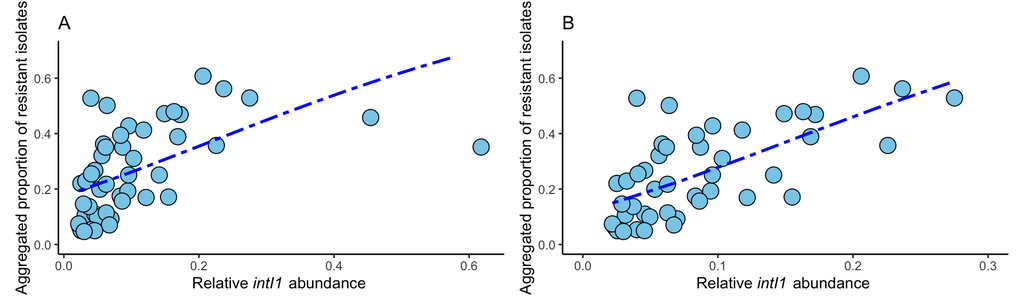

```r
p1 + p2
```

**Fig. 3: Aggregated resistance model based on intI1 integrase gene**

### E. coli clinical resistance models based on combined sewage and socioeconomical data

It is clear from the results that sewage data alone is not enough for modeling clinical resistance prevalence. To improve the performance, we included socioeconomic factors to the models. We used GDP, proportion of urban population and basic sanotation index in combination with the sewage data (*intI1*) to model clinical resistance prevalence in *E. coli* and more broadly using the aggregated resistance index.

#### Amniopenicillin resistance

```r
tmp <- ResData %>% filter(`AP_(n)`>100)
tmp$y = tmp$`AP_(R%)`/100

breg <- betareg(y ~  log(GDP) + urban_population + basic_sanitation + mean_int, data=tmp, link="loglog")
summary(breg)
```

```
##
## Call:
## betareg(formula = y ~ log(GDP) + urban_population + basic_sanitation +
##     mean_int, data = tmp, link = "loglog")
##
## Standardized weighted residuals 2:
##     Min      1Q  Median      3Q     Max
## -1.9702 -0.6482 -0.0020  0.5511  2.3723
##
## Coefficients (mean model with loglog link):
##                   Estimate Std. Error z value Pr(>|z|)
## (Intercept)       6.631215   1.099727   6.030 1.64e-09 ***
## log(GDP)         -0.277599   0.121371  -2.287 0.022184 *
## urban_population -0.007860   0.003898  -2.017 0.043745 *
## basic_sanitation -0.028746   0.008429  -3.410 0.000649 ***
## mean_int          4.202077   1.379923   3.045 0.002326 **
##
## Phi coefficients (precision model with identity link):
##       Estimate Std. Error z value Pr(>|z|)
## (phi)    49.43      12.08   4.091  4.3e-05 ***
## ---
## Signif. codes:  0 '***' 0.001 '**' 0.01 '*' 0.05 '.' 0.1 ' ' 1
##
## Type of estimator: ML (maximum likelihood)
## Log-likelihood:  44.5 on 6 Df
## Pseudo R-squared: 0.8474
## Number of iterations: 27 (BFGS) + 7 (Fisher scoring)
```

```r
new_int0 <- data.frame(mean_int=seq(min(tmp$mean_int), max(tmp$mean_int)+0.05, 0.05),
                       urban_population=quantile(tmp$urban_population)[2], basic_sanitation=quantile(tmp$basic_sanitation)[2],
                       GDP=quantile(tmp$GDP)[2])
new_int5 <- data.frame(mean_int=seq(min(tmp$mean_int), max(tmp$mean_int)+0.05, 0.05),
                      urban_population=quantile(tmp$urban_population)[3], basic_sanitation=quantile(tmp$basic_sanitation)[3],
                      GDP=quantile(tmp$GDP)[3])
new_int9 <- data.frame(mean_int=seq(min(tmp$mean_int), max(tmp$mean_int)+0.05, 0.05),
                       urban_population=quantile(tmp$urban_population)[4], basic_sanitation=quantile(tmp$basic_sanitation)[4],
                       GDP=quantile(tmp$GDP)[4])

new_int0$y <- predict(breg, newdata=new_int0)
new_int5$y <- predict(breg, newdata=new_int5)
new_int9$y <- predict(breg, newdata=new_int9)

p1 <- ggplot(tmp, aes(mean_int, y, size=basic_sanitation, fill=urban_population)) + geom_point(pch=21) +
  geom_line(aes(mean_int, y), data=new_int0, linetype="twodash", color="darkblue", size=1) +
  geom_line(aes(mean_int, y), data=new_int5, linetype="twodash", color="blue", size=1) +
  geom_line(aes(mean_int, y), data=new_int9, linetype="twodash", color="lightblue", size=1) + theme_classic() +
  scale_size(limits=c(min(tmp$basic_sanitation),max(tmp$basic_sanitation)),
             breaks=c(60, 80, 100), name="Basic sanitation") +
  scale_x_continuous(limits=c(0, 0.25)) +
  scale_fill_gradient(limits=c(min(tmp$urban_population), max(tmp$urban_population)),
                      breaks=c(20, 40, 60, 80,100), name="Urban population") +
  labs(x=expression(paste("Relative ", italic("intI1"), " abundance", sep=" ")), y="Proportion of resistant clinical isolates",
       title="A")
```

#### Fluoroquinolone resistance

```r
tmp <- ResData %>% filter(`FQ_(n)`>100)
tmp$y = tmp$`FQ_(R%)`/100

breg <- betareg(y ~ log(GDP) + urban_population + basic_sanitation + mean_int, data=tmp, link="loglog")
summary(breg)
```

```
##
## Call:
## betareg(formula = y ~ log(GDP) + urban_population + basic_sanitation +
##     mean_int, data = tmp, link = "loglog")
##
## Standardized weighted residuals 2:
##     Min      1Q  Median      3Q     Max
## -2.1288 -0.7550  0.0663  0.8374  1.8843
##
## Coefficients (mean model with loglog link):
##                    Estimate Std. Error z value Pr(>|z|)
## (Intercept)       2.3588129  1.0537833   2.238 0.025193 *
## log(GDP)         -0.2054641  0.1228022  -1.673 0.094302 .
## urban_population -0.0098242  0.0040179  -2.445 0.014481 *
## basic_sanitation -0.0008548  0.0068677  -0.124 0.900949
## mean_int          4.8309076  1.3844648   3.489 0.000484 ***
##
## Phi coefficients (precision model with identity link):
##       Estimate Std. Error z value Pr(>|z|)
## (phi)    28.50       6.83   4.172 3.02e-05 ***
## ---
## Signif. codes:  0 '***' 0.001 '**' 0.01 '*' 0.05 '.' 0.1 ' ' 1
##
## Type of estimator: ML (maximum likelihood)
## Log-likelihood: 38.85 on 6 Df
## Pseudo R-squared: 0.798
## Number of iterations: 27 (BFGS) + 2 (Fisher scoring)
```

```r
new_int0 <- data.frame(mean_int=seq(min(tmp$mean_int), max(tmp$mean_int)+0.05, 0.05),
                       urban_population=quantile(tmp$urban_population)[2], basic_sanitation=quantile(tmp$basic_sanitation)[2],
                       GDP=quantile(tmp$GDP)[2])
new_int5 <- data.frame(mean_int=seq(min(tmp$mean_int), max(tmp$mean_int)+0.05, 0.05),
                      urban_population=quantile(tmp$urban_population)[3], basic_sanitation=quantile(tmp$basic_sanitation)[3],
                      GDP=quantile(tmp$GDP)[3])
new_int9 <- data.frame(mean_int=seq(min(tmp$mean_int), max(tmp$mean_int)+0.05, 0.05),
                       urban_population=quantile(tmp$urban_population)[4], basic_sanitation=quantile(tmp$basic_sanitation)[4],
                       GDP=quantile(tmp$GDP)[4])

new_int0$y <- predict(breg, newdata=new_int0)
new_int5$y <- predict(breg, newdata=new_int5)
new_int9$y <- predict(breg, newdata=new_int9)

p2 <- ggplot(tmp, aes(mean_int, y, fill=urban_population, size=basic_sanitation)) + geom_point(pch=21) +
  geom_line(aes(mean_int, y), data=new_int0, linetype="twodash", color="darkblue", size=1) +
  geom_line(aes(mean_int, y), data=new_int5, linetype="twodash", color="blue", size=1) +
  geom_line(aes(mean_int, y), data=new_int9, linetype="twodash", color="lightblue", size=1) + theme_classic() +
  scale_size(limits=c(min(tmp$basic_sanitation),max(tmp$basic_sanitation)),
             breaks=c(60, 80, 100), name="Basic sanitation") +
  scale_x_continuous(limits=c(0, 0.25)) +
  scale_fill_gradient(limits=c(min(tmp$urban_population), max(tmp$urban_population)),
                      breaks=c(20, 40, 60, 80,100), name="Urban population") +
  labs(x=expression(paste("Relative ", italic("intI1"), " abundance", sep=" ")), y="Proportion of resistant clinical isolates",
       title="B")
```

#### 3rd generation cephalosporins

```r
tmp <- ResData %>% filter(`3GC_(n)`>100)
tmp$y = tmp$`3GC_(R%)`/100

breg <- betareg(y ~  log(GDP) + urban_population + basic_sanitation + mean_int, data=tmp, link="loglog")
summary(breg)
```

```
##
## Call:
## betareg(formula = y ~ log(GDP) + urban_population + basic_sanitation +
##     mean_int, data = tmp, link = "loglog")
##
## Standardized weighted residuals 2:
##     Min      1Q  Median      3Q     Max
## -3.3211 -0.4718  0.0347  0.3623  2.6310
##
## Coefficients (mean model with loglog link):
##                   Estimate Std. Error z value Pr(>|z|)
## (Intercept)       4.815852   1.117003   4.311 1.62e-05 ***
## log(GDP)         -0.345795   0.130314  -2.654  0.00797 **
## urban_population -0.006785   0.004179  -1.624  0.10447
## basic_sanitation -0.015339   0.007446  -2.060  0.03940 *
## mean_int          3.577753   1.441305   2.482  0.01305 *
##
## Phi coefficients (precision model with identity link):
##       Estimate Std. Error z value Pr(>|z|)
## (phi)   25.141      6.079   4.136 3.54e-05 ***
## ---
## Signif. codes:  0 '***' 0.001 '**' 0.01 '*' 0.05 '.' 0.1 ' ' 1
##
## Type of estimator: ML (maximum likelihood)
## Log-likelihood: 43.09 on 6 Df
## Pseudo R-squared: 0.8596
## Number of iterations: 26 (BFGS) + 2 (Fisher scoring)
```

```r
new_int0 <- data.frame(mean_int=seq(min(tmp$mean_int), max(tmp$mean_int)+0.05, 0.05),
                       urban_population=quantile(tmp$urban_population)[2], basic_sanitation=quantile(tmp$basic_sanitation)[2],
                       GDP=quantile(tmp$GDP)[2])
new_int5 <- data.frame(mean_int=seq(min(tmp$mean_int), max(tmp$mean_int)+0.05, 0.05),
                      urban_population=quantile(tmp$urban_population)[3], basic_sanitation=quantile(tmp$basic_sanitation)[3],
                      GDP=quantile(tmp$GDP)[3])
new_int9 <- data.frame(mean_int=seq(min(tmp$mean_int), max(tmp$mean_int)+0.05, 0.05),
                       urban_population=quantile(tmp$urban_population)[4], basic_sanitation=quantile(tmp$basic_sanitation)[4],
                       GDP=quantile(tmp$GDP)[4])

new_int0$y <- predict(breg, newdata=new_int0)
new_int5$y <- predict(breg, newdata=new_int5)
new_int9$y <- predict(breg, newdata=new_int9)

p3 <- ggplot(tmp, aes(mean_int, y, size=basic_sanitation, fill=urban_population)) + geom_point(pch=21) +
  geom_line(aes(mean_int, y), data=new_int0, linetype="twodash", color="darkblue", size=1) +
  geom_line(aes(mean_int, y), data=new_int5, linetype="twodash", color="blue", size=1) +
  geom_line(aes(mean_int, y), data=new_int9, linetype="twodash", color="lightblue", size=1) + theme_classic() +
  scale_size(limits=c(min(tmp$basic_sanitation),max(tmp$basic_sanitation)),
             breaks=c(60, 80, 100), name="Basic sanitation") +
  scale_x_continuous(limits=c(0, 0.25)) +
  scale_fill_gradient(limits=c(min(tmp$urban_population), max(tmp$urban_population)),
                      breaks=c(20, 40, 60, 80,100), name="Urban population") +
  labs(x=expression(paste("Relative ", italic("intI1"), " abundance", sep=" ")), y="Proportion of resistant clinical isolates",
       title="C")
```

#### Amoinoglycoside resistance

```r
tmp <- ResData %>% filter(`AG_(n)`>100)
tmp$y = tmp$`AG_(R%)`/100

breg <- betareg(y ~  log(GDP) + urban_population + basic_sanitation + mean_int, data=tmp, link="loglog")
summary(breg)
```

```
##
## Call:
## betareg(formula = y ~ log(GDP) + urban_population + basic_sanitation +
##     mean_int, data = tmp, link = "loglog")
##
## Standardized weighted residuals 2:
##     Min      1Q  Median      3Q     Max
## -2.9172 -0.7608 -0.1140  0.5325  2.6332
##
## Coefficients (mean model with loglog link):
##                   Estimate Std. Error z value Pr(>|z|)
## (Intercept)       3.558608   0.909783   3.911 9.17e-05 ***
## log(GDP)         -0.444008   0.102452  -4.334 1.47e-05 ***
## urban_population -0.004142   0.003330  -1.244    0.214
## basic_sanitation  0.006487   0.005199   1.248    0.212
## mean_int          0.469429   1.118507   0.420    0.675
##
## Phi coefficients (precision model with identity link):
##       Estimate Std. Error z value Pr(>|z|)
## (phi)    39.90       9.84   4.055 5.02e-05 ***
## ---
## Signif. codes:  0 '***' 0.001 '**' 0.01 '*' 0.05 '.' 0.1 ' ' 1
##
## Type of estimator: ML (maximum likelihood)
## Log-likelihood: 51.44 on 6 Df
## Pseudo R-squared: 0.6815
## Number of iterations: 27 (BFGS) + 2 (Fisher scoring)
```

```r
new_int0 <- data.frame(mean_int=seq(min(tmp$mean_int), max(tmp$mean_int)+0.05, 0.05),
                       urban_population=quantile(tmp$urban_population)[2], basic_sanitation=quantile(tmp$basic_sanitation)[2],
                       GDP=quantile(tmp$GDP)[2])
new_int5 <- data.frame(mean_int=seq(min(tmp$mean_int), max(tmp$mean_int)+0.05, 0.05),
                      urban_population=quantile(tmp$urban_population)[3], basic_sanitation=quantile(tmp$basic_sanitation)[3],
                      GDP=quantile(tmp$GDP)[3])
new_int9 <- data.frame(mean_int=seq(min(tmp$mean_int), max(tmp$mean_int)+0.05, 0.05),
                       urban_population=quantile(tmp$urban_population)[4], basic_sanitation=quantile(tmp$basic_sanitation)[4],
                       GDP=quantile(tmp$GDP)[4])

new_int0$y <- predict(breg, newdata=new_int0)
new_int5$y <- predict(breg, newdata=new_int5)
new_int9$y <- predict(breg, newdata=new_int9)

p4 <- ggplot(tmp, aes(mean_int, y, size=basic_sanitation, fill=urban_population)) + geom_point(pch=21) +
  geom_line(aes(mean_int, y), data=new_int0, linetype="twodash", color="darkblue", size=1) +
  geom_line(aes(mean_int, y), data=new_int5, linetype="twodash", color="blue", size=1) +
  geom_line(aes(mean_int, y), data=new_int9, linetype="twodash", color="lightblue", size=1) + theme_classic() +
  scale_size(limits=c(min(tmp$basic_sanitation),max(tmp$basic_sanitation)),
             breaks=c(60, 80, 100), name="Basic sanitation") +
  scale_x_continuous(limits=c(0, 0.25)) +
  scale_fill_gradient(limits=c(min(tmp$urban_population), max(tmp$urban_population)),
                      breaks=c(20, 40, 60, 80,100), name="Urban population") +
  labs(x=expression(paste("Relative ", italic("intI1"), " abundance", sep=" ")), y="Proportion of resistant clinical isolates",
       title="D")
```

#### Figure 4

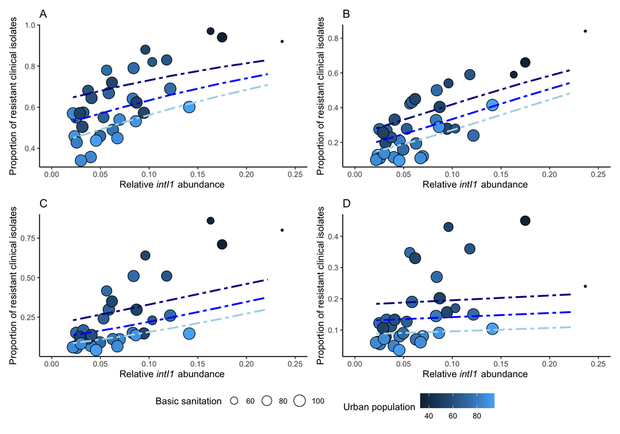

```r
(p1 + p2) /  (p3 + p4) +
  plot_layout(guides = 'collect') & theme(legend.position='bottom')
```

**Fig. 4: E. coli clinical resistance models based on combined sewage and socioeconomical data**

#### Aggregated resistance index

```r
tmp <- ResData
tmp$y = tmp$AverageAll/100
tmp <- tmp %>% filter(!(Country=="Nigeria" | Country=="Peru" | Country=="Kosovo"))

breg <- betareg(y ~  log(GDP) + urban_population + basic_sanitation + mean_int, data=tmp, link="loglog")
summary(breg)
```

```
##
## Call:
## betareg(formula = y ~ log(GDP) + urban_population + basic_sanitation +
##     mean_int, data = tmp, link = "loglog")
##
## Standardized weighted residuals 2:
##     Min      1Q  Median      3Q     Max
## -1.9243 -0.8309  0.0747  0.6642  2.1436
##
## Coefficients (mean model with loglog link):
##                   Estimate Std. Error z value Pr(>|z|)
## (Intercept)       2.499088   0.745364   3.353 0.000800 ***
## log(GDP)         -0.364228   0.099317  -3.667 0.000245 ***
## urban_population -0.008212   0.003016  -2.723 0.006478 **
## basic_sanitation  0.012280   0.004040   3.039 0.002371 **
## mean_int          3.333969   0.892383   3.736 0.000187 ***
##
## Phi coefficients (precision model with identity link):
##       Estimate Std. Error z value Pr(>|z|)
## (phi)   28.345      5.929   4.781 1.75e-06 ***
## ---
## Signif. codes:  0 '***' 0.001 '**' 0.01 '*' 0.05 '.' 0.1 ' ' 1
##
## Type of estimator: ML (maximum likelihood)
## Log-likelihood:  54.7 on 6 Df
## Pseudo R-squared: 0.7589
## Number of iterations: 14 (BFGS) + 4 (Fisher scoring)
```

```r
new_int0 <- data.frame(mean_int=seq(min(tmp$mean_int), max(tmp$mean_int)+0.05, 0.05),
                       basic_sanitation=quantile(tmp$basic_sanitation)[2],
                       urban_population=quantile(tmp$urban_population)[2], GDP=quantile(tmp$GDP)[2])
new_int5 <- data.frame(mean_int=seq(min(tmp$mean_int), max(tmp$mean_int)+0.05, 0.05),
                       basic_sanitation=quantile(tmp$basic_sanitation)[3],
                      urban_population=quantile(tmp$urban_population)[3], GDP=quantile(tmp$GDP)[3])
new_int9 <- data.frame(mean_int=seq(min(tmp$mean_int), max(tmp$mean_int)+0.05, 0.05),
                       basic_sanitation=quantile(tmp$basic_sanitation)[4],
                       urban_population=quantile(tmp$urban_population)[4], GDP=quantile(tmp$GDP)[4])

new_int0$y <- predict(breg, newdata=new_int0)
new_int5$y <- predict(breg, newdata=new_int5)
new_int9$y <- predict(breg, newdata=new_int9)
```

#### Figure 5

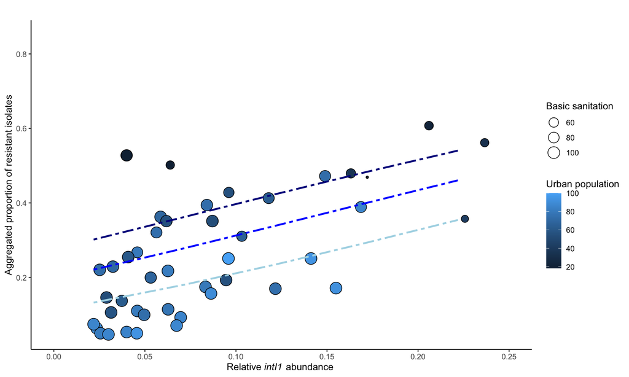

```r
ggplot(tmp, aes(mean_int, y, size=basic_sanitation, fill=urban_population)) + geom_point(pch=21) +
  geom_line(aes(mean_int, y), data=new_int0, linetype="twodash", color="darkblue", size=1) +
  geom_line(aes(mean_int, y), data=new_int5, linetype="twodash", color="blue", size=1) +
  geom_line(aes(mean_int, y), data=new_int9, linetype="twodash", color="lightblue", size=1) + theme_classic() +
  scale_size(limits=c(min(tmp$basic_sanitation),max(tmp$basic_sanitation)),
             breaks=c(60, 80, 100), name="Basic sanitation") +
  scale_x_continuous(limits=c(0, 0.25)) +
  scale_fill_gradient(limits=c(min(tmp$urban_population), max(tmp$urban_population)),
                      breaks=c(20, 40, 60, 80,100), name="Urban population") +
  labs(x=expression(paste("Relative ", italic("intI1"), " abundance", sep=" ")), y="Aggregated proportion of resistant isolates",
       title="")
```

**Fig. 5: Aggregated resistance model based on combined sewage and socioeconomical data**

### Predictions of clinical resistance prevalence for countries without clinical resistance data

After the promising results from our clinical resistance models, we were confident enough to try and predict clinical resistance prevalence in countries where we didn’t have any reliable data on clinical resistance prevalence.

#### Figure 6

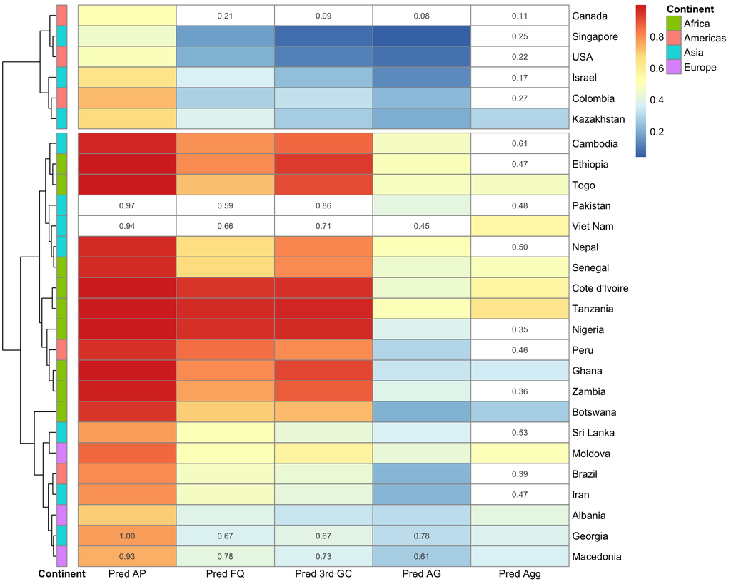

```r
no_data <- data.frame(ResData[!complete.cases(ResData[,c("AP_(R%)", "FQ_(R%)", "3GC_(R%)", "AG_(R%)", "AverageAll")]),])
no_data <- no_data %>% filter(!(Country=="Gambia" | Country=="Chad" | Country == "Kosovo"))

# AP
tmp <- ResData %>% filter(`AP_(n)`>100)
tmp$y = tmp$`AP_(R%)`/100
breg <- betareg(y ~  log(GDP) + urban_population + basic_sanitation + mean_int, data=tmp, link="loglog")
pred_AP <- predict(breg, no_data)

# FQ
tmp <- ResData %>% filter(`FQ_(n)`>100)
tmp$y = tmp$`FQ_(R%)`/100
breg <- betareg(y ~  log(GDP) + urban_population + basic_sanitation + mean_int, data=tmp, link="loglog")
pred_FQ <- predict(breg, no_data)

# 3GC
tmp <- ResData %>% filter(`3GC_(n)`>100)
tmp$y = tmp$`3GC_(R%)`/100
breg <- betareg(y ~ log(GDP) + urban_population + basic_sanitation + mean_int, data=tmp, link="loglog")
pred_3GC <- predict(breg, no_data)

# AG
tmp <- ResData %>% filter(`AG_(n)`>100)
tmp$y = tmp$`AG_(R%)`/100
breg <- betareg(y ~   log(GDP) + urban_population + basic_sanitation + mean_int, data=tmp, link="loglog")
pred_AG <- predict(breg, no_data)

# AverageAll
tmp <-  ResData
tmp$y = tmp$AverageAll/100
breg <- betareg(y ~  log(GDP) + urban_population + basic_sanitation + mean_int, data=tmp, link="loglog")
pred_AA <- predict(breg, no_data)

pred_data <- cbind(no_data, pred_AP, pred_FQ, pred_3GC, pred_AG, pred_AA)
pred_data <- pred_data %>% filter(!is.na(pred_data[,"pred_AP"]))
row.names(pred_data) <- pred_data$Country
pred <- pred_data[,c("pred_AP", "pred_FQ", "pred_3GC", "pred_AG", "pred_AA")]
annotation_row <- data.frame(Continent=pred_data$Continent, row.names=row.names(pred_data))
orig_values <- data.frame(no_data[,c("AP_.R..", "FQ_.R..","X3GC_.R..", "AG_.R..", "AverageAll")], row.names=no_data$Country)
orig_values <- format(round(orig_values/100, digits=2), nsmall=2)
orig_values[orig_values<0] <- ""

clust_mat <- pred
clust_mat[orig_values>0] <- orig_values[orig_values>0]
countries <- c("Georgia", "Macedonia")
clust_mat[countries,] <- pred_data[countries,c("pred_AP", "pred_FQ", "pred_3GC", "pred_AG", "pred_AA")]
clust_obj <- hclust(dist(clust_mat))

pred[orig_values>0] <- NA
# put Georgia and Macedonia back to the model
countries <- c("Georgia", "Macedonia")
pred[countries,] <- pred_data[countries,c("pred_AP", "pred_FQ", "pred_3GC", "pred_AG", "pred_AA")]

pheatmap(pred, cluster_cols=FALSE, cluster_rows=clust_obj,annotation_row = annotation_row, display_numbers=orig_values,
        labels_col=c("Pred AP", "Pred FQ", "Pred 3rd GC", "Pred AG", "Pred Agg"), gaps_col=c(0,0),
        angle_col=0, cutree_rows=2, na_col="white")
```

**Fig. 6: Predictions of clinical resistance prevalence for countries without clinical resistance data**

### Global predictions for aggregated resistance index

And for giving an overview of global clinical resistance situation, the same was done for all countries where we had sewage and socio-economical data.

#### Figure 7

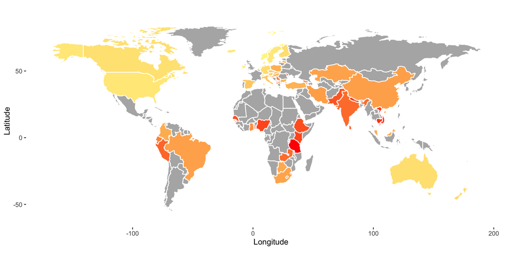

```r
all_data <- ResData %>% filter(!(Country=="Gambia" | Country=="Chad" | Country == "Kosovo")) %>% data.frame()

tmp <-  ResData
tmp$y = tmp$AverageAll/100
breg <- betareg(y ~  log(GDP) + urban_population + basic_sanitation + mean_int, data=tmp, link="loglog")
pred_AA <- predict(breg, all_data)

all_data <- cbind(all_data, pred_AA)

RES_map <- map_data("world")
RES_map <- RES_map %>% filter(region!="Antarctica")
tmp <- data.frame(region=all_data$Country, pred_AA=all_data$pred_AA)
tmp$region <- plyr::revalue(tmp$region, c("Viet Nam" = "Vietnam"))
RES_map <- full_join(RES_map, tmp, by="region")

# main figure
ggplot() +
  geom_polygon(data = RES_map, aes(x=long, y = lat, group = group, fill=pred_AA), color="white") +
  theme(panel.grid = element_blank(), panel.background = element_blank(),
        plot.title = element_text(size=10, face = "bold"), legend.position = "none") +
  scale_x_continuous(limits=c(-170, 200)) + scale_y_continuous(limits=c(-60, 85)) +
  labs(x="Longitude", y="Latitude", title = "", caption = "") +
  scale_fill_gradient(name="scale", high="red", low="#FFFF99", na.value = "grey70")
```

**Fig. 7: Global predictions for aggregated resistance index**

## Supplementary Materials

The supplementary materials are presented below.

### Suppl. Fig. 7.

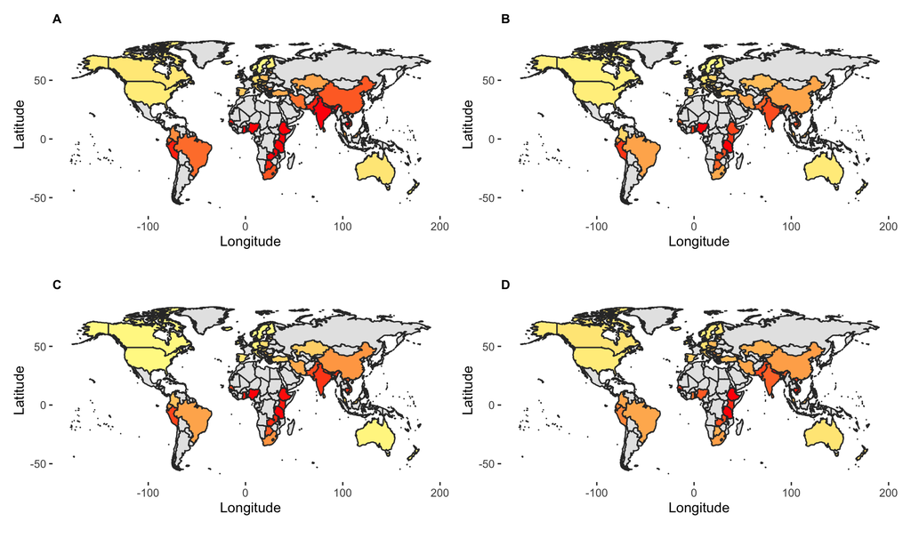

```r
all_data <- ResData %>% filter(!(Country=="Gambia" | Country=="Chad" | Country == "Kosovo")) %>% data.frame()
# AP
tmp <- ResData %>% filter(`AP_(n)`>100)
tmp$y = tmp$`AP_(R%)`/100
breg <- betareg(y ~ log(GDP) + urban_population + basic_sanitation + mean_int, data=tmp, link="loglog")
pred_AP <- predict(breg, all_data)

# FQ
tmp <- ResData %>% filter(`FQ_(n)`>100)
tmp$y = tmp$`FQ_(R%)`/100
breg <- betareg(y ~ log(GDP) + urban_population + basic_sanitation + mean_int, data=tmp, link="loglog")
pred_FQ <- predict(breg, all_data)

# 3GC
tmp <- ResData %>% filter(`3GC_(n)`>100)
tmp$y = tmp$`3GC_(R%)`/100
breg <- betareg(y ~ log(GDP) + urban_population + basic_sanitation + mean_int, data=tmp, link="loglog")
pred_3GC <- predict(breg, all_data)

# AG
tmp <- ResData %>% filter(`AG_(n)`>100)
tmp$y = tmp$`AG_(R%)`/100
breg <- betareg(y ~ log(GDP) + urban_population + basic_sanitation + mean_int, data=tmp, link="loglog")
pred_AG <- predict(breg, all_data)

all_data <- cbind(all_data, pred_AP, pred_FQ, pred_3GC, pred_AG)

RES_map <- map_data("world")
RES_map <- RES_map %>% filter(region!="Antarctica")
tmp <- data.frame(region=all_data$Country, pred_AP=all_data$pred_AP, pred_FQ=all_data$pred_FQ, pred_3GC=all_data$pred_3GC, pred_AG=all_data$pred_AG)
tmp$region <- plyr::revalue(tmp$region, c("Viet Nam" = "Vietnam"))
RES_map <- full_join(RES_map, tmp, by="region")


# supplemental figures
p1 <- ggplot() +
  geom_polygon(data = RES_map, aes(x=long, y = lat, group = group, fill=pred_AP), color="grey20") +
  #scale_y_continuous(limits = c(34,71)) +
  theme(panel.grid = element_blank(), panel.background = element_blank(),
        plot.title = element_text(size=10, face = "bold"), legend.position = "none") +
  labs(x="Longitude", y="Latitude", title = "A", caption = "") +
  scale_fill_gradient(name="scale", high="red", low="#FFFF99", na.value = "grey90")

p2 <- ggplot() +
    geom_polygon(data = RES_map, aes(x=long, y = lat, group = group, fill=pred_FQ), color="grey20") +
    #scale_y_continuous(limits = c(34,71)) +
    theme(panel.grid = element_blank(), panel.background = element_blank(),
          plot.title = element_text(size=10, face = "bold"), legend.position = "none") +
    labs(x="Longitude", y="Latitude", title = "B", caption = "") +
    scale_fill_gradient(name="scale", high="red", low="#FFFF99", na.value = "grey90")

p3 <- ggplot() +
    geom_polygon(data = RES_map, aes(x=long, y = lat, group = group, fill=pred_3GC), color="grey20") +
    #scale_y_continuous(limits = c(34,71)) +
    theme(panel.grid = element_blank(), panel.background = element_blank(),
          plot.title = element_text(size=10, face = "bold"), legend.position = "none") +
    labs(x="Longitude", y="Latitude", title = "C", caption = "") +
    scale_fill_gradient(name="scale", high="red", low="#FFFF99", na.value = "grey90")

p4 <- ggplot() +
    geom_polygon(data = RES_map, aes(x=long, y = lat, group = group, fill=pred_AG), color="grey20") +
    #scale_y_continuous(limits = c(34,71)) +
    theme(panel.grid = element_blank(), panel.background = element_blank(),
          plot.title = element_text(size=10, face = "bold"), legend.position = "none") +
    labs(x="Longitude", y="Latitude", title = "D", caption = "") +
    scale_fill_gradient(name="scale", high="red", low="#FFFF99", na.value = "grey90")

(p1 | p2) / (p3 | p4)
```